# Preliminary Simulation Results

## Simulation Scenario

For all simulations the number of predictors ($p=1000$), sample size ($n = 400$), the number of subjects who were exposed ($n_{E=1}=200$) and unexposed ($n_{E=0}=200$) and the number of truly associated parameters ($S_0 = 20$) remained fixed. We generate original predictors $X_j, j=1, \ldots, p$ from a multivariate normal distribution. The correlation between predictors has a block diagonal structure such that within a block, the correlation between $X_j$ and $X_{j'}$ is $\rho_E$ for $j \neq j'$, where $\rho_E$ depends on exposure status. Let $Y^* = \beta_E E + \sum_j \beta_j X_j + \alpha_{jE} X_j E$. We generate a continuous response $Y = Y^* + k \cdot \varepsilon$ where the error term $\varepsilon$ is generated from a standard normal distribution, and $k$ is chosen such that the signal-to-noise ratio $\left(Var(Y^*)/Var(\varepsilon)\right)$ is 0.5. We explored block sizes $50,100,200$, resulting in $B=20, 10, 5$ blocks, respectively.

Currently, only the differentially correlated block contains the active set.

Recall that the method is the general approach (univariate, penalization, clustering then regression, or environment clustering). The model is what was used to get the coefficient estimates (linear model, lasso, shim which is the strong heredity interaction model). For example, you will notice in the MSE plot, `avg_shim` has two error bars. One corresponds to using average clusters as predictors, and the other corresponds to using average environment clusters as predictors.

1. `rho`: the correlation for the exposed subjects for the differentially correlated block
2. `rhoOther`: correlation for all other blocks.
3. `betaMean`: the active main effect coefficients are generated from a Uniform(3.9,4.1) distribution
4. `betaE`: coefficient of binary environment variable
5. `alphaMean`: the interaction effect coefficients are generated from a Uniform(1.9,2.1) distribution

| rho | blocksize | p | n | n0 | rhoOther | betaMean | betaE | alphaMean | nActive | includeInteraction | includeStability | nBlocks |
| --- | --- | --- | --- | --- | --- | --- | --- | --- | --- | --- | --- | --- |
| 0.10 | 50 | 1000 | 400 | 200 | 0.6 | 4 | 5 | 2 | 20 | TRUE | TRUE | 20 |
| 0.35 | 50 | 1000 | 400 | 200 | 0.6 | 4 | 5 | 2 | 20 | TRUE | TRUE | 20 |
| 0.75 | 50 | 1000 | 400 | 200 | 0.6 | 4 | 5 | 2 | 20 | TRUE | TRUE | 20 |
| 0.95 | 50 | 1000 | 400 | 200 | 0.6 | 4 | 5 | 2 | 20 | TRUE | TRUE | 20 |

Currently we only have results for about 20 simulations for each combination of block size and rho parameter.

## True Positive Rate vs. Number of non-zero fitted coefficients

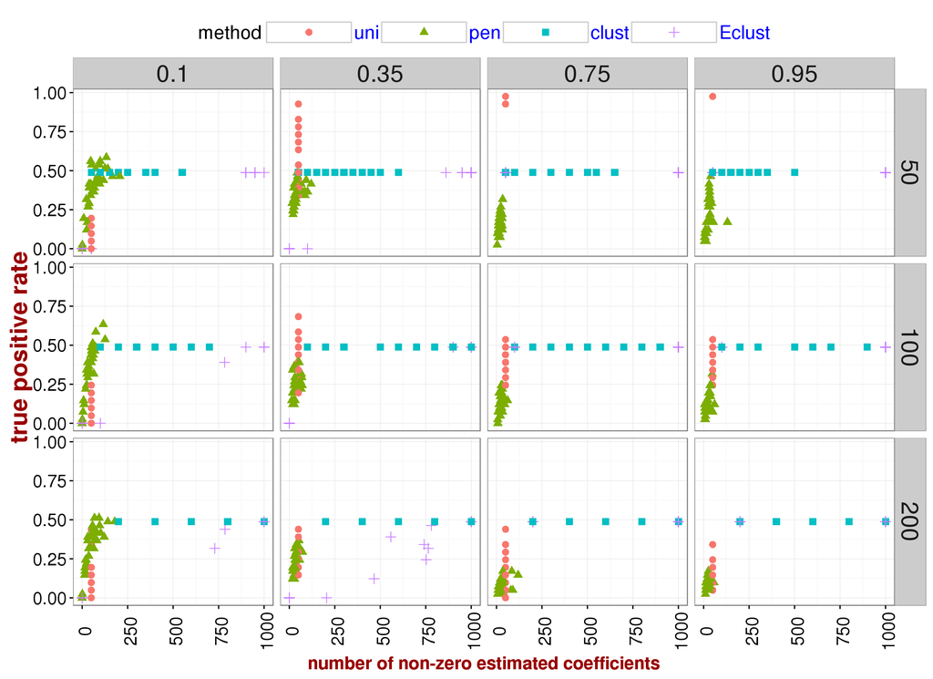

## MSE

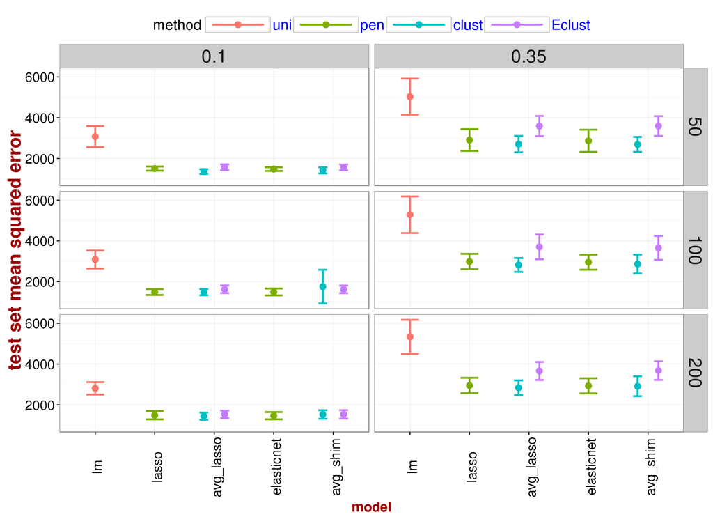

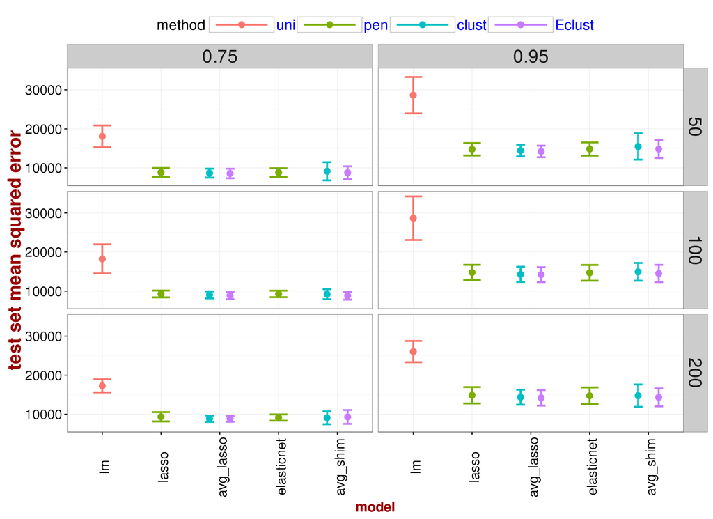

## Stability Measures

### Jaccard Index

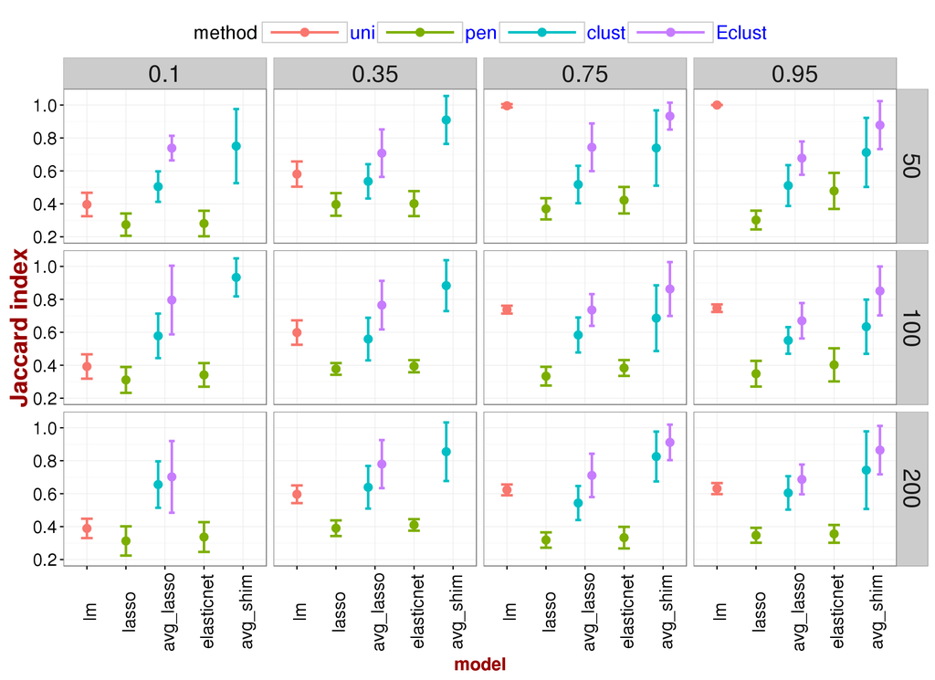

### Spearman Correlation

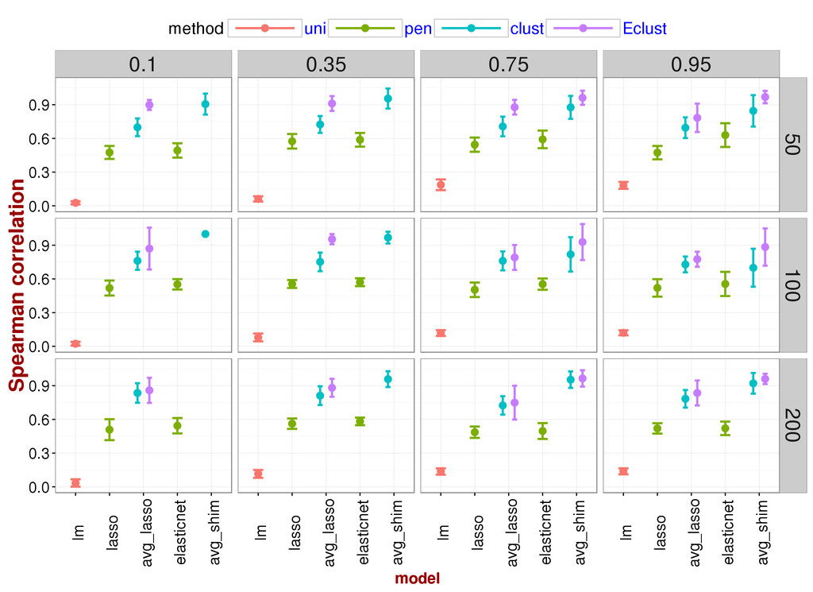

### Pearson correlation

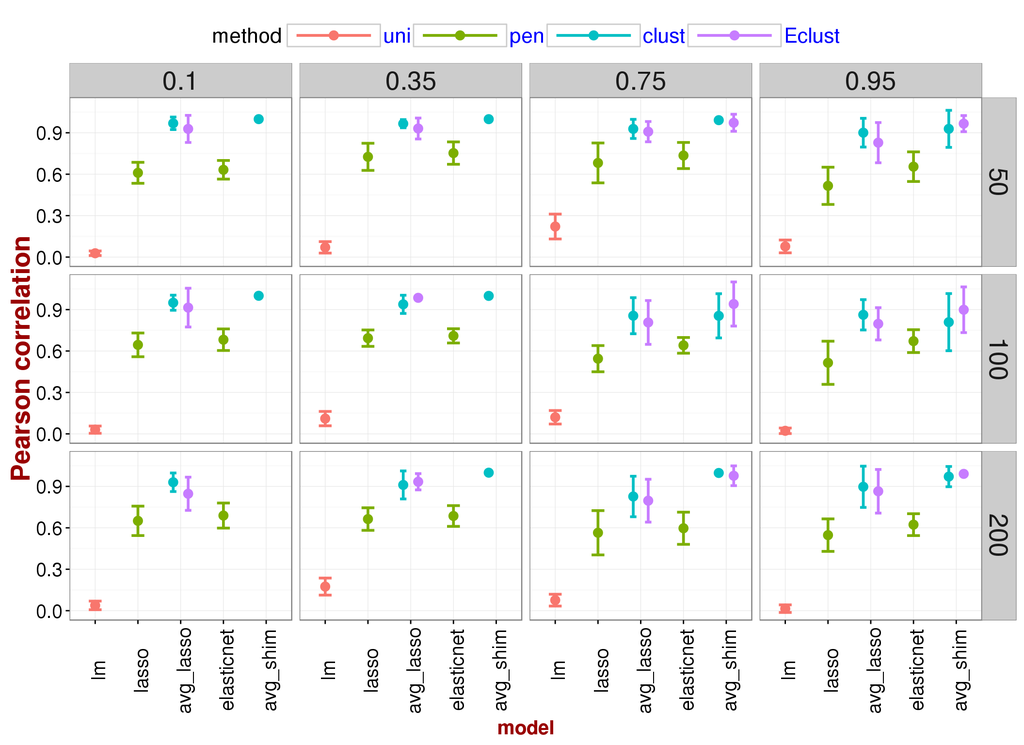